# NZIPL Predicted Competitiveness — ML Pipeline Review

Random Forest · SHAP Feature Importance · Replication Roadmap

Author

NZIPL Clean Value Chain Explorer

Published

May 20, 2026

# 1 Executive Summary

This document reviews the **Predicted Competitiveness (PC) machine learning pipeline** developed by NZIPL for the Atlas of the Global Clean Industrial Base. The pipeline:

1. Uses **BACI bilateral trade data** to compute Revealed Comparative Advantage (RCA) per country × HS6 product × year
2. Trains a **Random Forest classifier** for each of the 10 clean technologies to predict whether a country will achieve RCA > 1 (i.e., become competitively specialised)
3. Applies **SHAP (SHapley Additive exPlanations)** to extract which product-level RCA variables most drive each prediction
4. Exports `predicted_comp` scores (0–1 probability) and per-feature `shap_mean_z` importance values — the two datasets now embedded in CVCE

# 2 Notebook Inventory

The Python notebooks are located at: `OneDrive/Bentley Allan's files - NZIPL/Projects/001 Industrial Base/Modeling -- ML`

```r
notebooks <- tribble(
  ~Group,              ~Notebook,                        ~Purpose,
  "Core ML",    "Analysis/RCA Batteries Analysis.ipynb", "RF model + SHAP + rankings (Batteries)",
  "Core ML",    "Analysis/RCA Solar Analysis.ipynb",     "RF model + SHAP + rankings (Solar)",
  "Core ML",    "Analysis/RCA Wind Analysis.ipynb",      "RF model + SHAP + rankings (Wind)",
  "Core ML",    "Analysis/RCA {Tech} Analysis.ipynb",    "Same pattern for remaining 7 techs",
  "Features",   "RCA Construction/Battery/Batteries_Vars.ipynb", "Feature matrix: lagged RCA for 69 battery HS codes + 20 proximate + macro",
  "Features",   "RCA Construction/{Tech}/{Tech}_Vars.ipynb",     "Same pattern for each of 10 techs",
  "Data Prep",  "RCA/Code + Cleaned Files/RCA.ipynb",    "Base RCA calculation from BACI",
  "Data Prep",  "ML Code/Product Proximity Update.ipynb","Product proximity (phi) matrix calculation",
  "Data Prep",  "ML Data/Bentley_Backup/Imputation script.ipynb", "KNN imputation (k=3) for missing trade values",
  "Data Prep",  "ML Data/Trade Data/GTA code.ipynb",     "Global Trade Alert policy intervention processing",
  "Viz",        "ML Code/Nature Paper Figures.ipynb",    "Publication bubble charts (country × tech × score)",
  "Viz",        "ML Code/Old/Country Deep Dives.ipynb",  "RCA time series per country",
  "Utility",    "FDI Methodology/Firm Names/Fuzzymatch.ipynb", "Fuzzy name matching for FDI firm data"
)

notebooks |>
  kable(col.names = c("Group", "Notebook", "Purpose"),
        caption = "NZIPL ML Pipeline — Notebook Inventory") |>
  kable_styling(bootstrap_options = c("striped", "hover", "condensed"),
                full_width = TRUE, font_size = 13) |>
  column_spec(1, bold = TRUE, color = nzipl_green) |>
  row_spec(0, bold = TRUE, background = nzipl_green, color = "white")
```

NZIPL ML Pipeline — Notebook Inventory

| Group | Notebook | Purpose |
| --- | --- | --- |
| Core ML | Analysis/RCA Batteries Analysis.ipynb | RF model + SHAP + rankings (Batteries) |
| Core ML | Analysis/RCA Solar Analysis.ipynb | RF model + SHAP + rankings (Solar) |
| Core ML | Analysis/RCA Wind Analysis.ipynb | RF model + SHAP + rankings (Wind) |
| Core ML | Analysis/RCA {Tech} Analysis.ipynb | Same pattern for remaining 7 techs |
| Features | RCA Construction/Battery/Batteries_Vars.ipynb | Feature matrix: lagged RCA for 69 battery HS codes + 20 proximate + macro |
| Features | RCA Construction/{Tech}/{Tech}_Vars.ipynb | Same pattern for each of 10 techs |
| Data Prep | RCA/Code + Cleaned Files/RCA.ipynb | Base RCA calculation from BACI |
| Data Prep | ML Code/Product Proximity Update.ipynb | Product proximity (phi) matrix calculation |
| Data Prep | ML Data/Bentley_Backup/Imputation script.ipynb | KNN imputation (k=3) for missing trade values |
| Data Prep | ML Data/Trade Data/GTA code.ipynb | Global Trade Alert policy intervention processing |
| Viz | ML Code/Nature Paper Figures.ipynb | Publication bubble charts (country × tech × score) |
| Viz | ML Code/Old/Country Deep Dives.ipynb | RCA time series per country |
| Utility | FDI Methodology/Firm Names/Fuzzymatch.ipynb | Fuzzy name matching for FDI firm data |

# 3 Pipeline Architecture

## 3.1 End-to-end flow

```
┌──────────────────────────────────────────────────────────┐
│  1. RAW DATA                                             │
│     BACI bilateral trade (HS6, 2002–2023)               │
│     FDI % GDP · Tariffs · Manufacturing % GDP           │
└──────────────────────┬───────────────────────────────────┘
                       │
                       ▼
┌──────────────────────────────────────────────────────────┐
│  2. RCA CALCULATION   (RCA.ipynb)                       │
│                                                          │
│     RCA(c,p,y) = [X_cpy / X_c·] / [X_·p· / X_···]     │
│                                                          │
│     → rca_cyh.csv  (all country-product-year RCAs)      │
│     → phi_equal_year.csv  (product proximity matrix)    │
└──────────────────────┬───────────────────────────────────┘
                       │
                       ▼
┌──────────────────────────────────────────────────────────┐
│  3. FEATURE ENGINEERING  ({Tech}_Vars.ipynb × 10)       │
│                                                          │
│     b_{HS6}  (×60-90)  : lagged RCA for tech HS codes  │
│     nb_{HS6} (×15-25)  : lagged RCA for proximate prods│
│     FDI, tariffs, manufacturing % GDP, trade openness  │
│                                                          │
│     → battery_trade.csv, solar_trade.csv, …  (~90 cols) │
└──────────────────────┬───────────────────────────────────┘
                       │
                       ▼
┌──────────────────────────────────────────────────────────┐
│  4. KNN IMPUTATION  (Imputation script.ipynb)           │
│     k = 3 · fills missing export values                 │
│     → final_trade_df_imputed.csv                        │
└──────────────────────┬───────────────────────────────────┘
                       │
                       ▼
┌──────────────────────────────────────────────────────────┐
│  5. RANDOM FOREST CLASSIFICATION  (Analysis notebooks)  │
│                                                          │
│     Target:   y = int(RCA_tech > 1)                     │
│     Model:    RFC(n_estimators=100, max_depth=10,        │
│                   random_state=28, test_size=0.25)       │
│                                                          │
│     → predicted_comp = predict_proba(X)[:, 1]           │
│       (probability of competitive specialisation)       │
└──────────────────────┬───────────────────────────────────┘
                       │
                       ▼
┌──────────────────────────────────────────────────────────┐
│  6. SHAP FEATURE IMPORTANCE  (same Analysis notebooks)  │
│                                                          │
│     explainer = shap.TreeExplainer(rf_model)            │
│     shap_vals = explainer.shap_values(X)[1]  ← class 1 │
│                                                          │
│     z-normalise by year:  z = (x − μ_year) / σ_year    │
│     shap_mean_z = mean(|z|)  per feature                │
│                                                          │
│     → per-tech SHAP importance CSVs                     │
│       (now consolidated in data/pc/pc_features.csv)     │
└──────────────────────────────────────────────────────────┘
```

## 3.2 Model specification

```r
specs <- tribble(
  ~Parameter,         ~Value,         ~Notes,
  "Algorithm",        "RandomForestClassifier", "scikit-learn; tree-based, scale-invariant",
  "n_estimators",     "100",          "Number of decision trees",
  "max_depth",        "10",           "Max tree depth; limits overfitting",
  "random_state",     "28",           "Fixed for reproducibility across all techs",
  "Train/test split", "75% / 25%",    "Stratified random split",
  "Cross-validation", "5-fold GridSearchCV", "Only for Solar & Wind; others use fixed params",
  "Target variable",  "int(RCA > 1)", "Binary: 1 = competitive, 0 = not",
  "Output",           "predict_proba[:, 1]", "Probability of competitiveness; range 0–1",
  "Lag structure",    "1-year lag on all IV features", "Avoids look-ahead bias",
  "Missing data",     "KNN (k=3)",    "Pre-imputed before model training"
)

specs |>
  kable(col.names = c("Parameter", "Value", "Notes"),
        caption = "Random Forest Model Specification") |>
  kable_styling(bootstrap_options = c("striped","hover","condensed"),
                full_width = TRUE, font_size = 13) |>
  column_spec(1, bold = TRUE) |>
  row_spec(0, bold = TRUE, background = nzipl_green, color = "white")
```

Random Forest Model Specification

| Parameter | Value | Notes |
| --- | --- | --- |
| Algorithm | RandomForestClassifier | scikit-learn; tree-based, scale-invariant |
| n_estimators | 100 | Number of decision trees |
| max_depth | 10 | Max tree depth; limits overfitting |
| random_state | 28 | Fixed for reproducibility across all techs |
| Train/test split | 75% / 25% | Stratified random split |
| Cross-validation | 5-fold GridSearchCV | Only for Solar & Wind; others use fixed params |
| Target variable | int(RCA > 1) | Binary: 1 = competitive, 0 = not |
| Output | predict_proba[:, 1] | Probability of competitiveness; range 0–1 |
| Lag structure | 1-year lag on all IV features | Avoids look-ahead bias |
| Missing data | KNN (k=3) | Pre-imputed before model training |

# 4 SHAP Feature Importance — What We Have

The `data/pc/pc_features.csv` contains the SHAP mean |z-score| for each HS6 code × technology combination that passed the importance threshold.

## 4.1 Coverage

```r
feat |>
  filter(!is.na(hs_code)) |>
  group_by(tech) |>
  summarise(
    `HS codes` = n_distinct(hs_code),
    `SHAP range` = paste0(round(min(shap_mean_z), 3), " – ",
                          round(max(shap_mean_z), 3)),
    `Mean SHAP` = round(mean(shap_mean_z), 3),
    `Top category` = {
      df <- cur_data() |> group_by(category) |>
        summarise(s = mean(shap_mean_z)) |> slice_max(s, n = 1)
      df$category[1]
    },
    .groups = "drop"
  ) |>
  rename(Technology = tech) |>
  kable(caption = "SHAP feature coverage per technology") |>
  kable_styling(bootstrap_options = c("striped","hover","condensed"),
                full_width = TRUE, font_size = 13) |>
  row_spec(0, bold = TRUE, background = nzipl_green, color = "white")
```

SHAP feature coverage per technology

| Technology | HS codes | SHAP range | Mean SHAP | Top category |
| --- | --- | --- | --- | --- |
| Batteries | 31 | 0.504 – 0.656 | 0.565 | Machinery |
| Biofuel | 66 | 0.512 – 0.811 | 0.645 | Machinery |
| Electrolyzers | 42 | 0.504 – 0.717 | 0.576 | Chemicals |
| Geothermal | 54 | 0.502 – 0.725 | 0.601 | Electronics |
| Heat Pumps | 26 | 0.515 – 0.822 | 0.644 | Machinery |
| Magnets | 8 | 0.529 – 0.667 | 0.583 | Chemicals |
| Nuclear | 22 | 0.506 – 0.699 | 0.556 | Machinery |
| Solar | 34 | 0.504 – 0.672 | 0.554 | Machinery |
| Transmission | 24 | 0.55 – 0.817 | 0.696 | Industrial Materials |
| Wind | 50 | 0.501 – 0.696 | 0.558 | Chemicals |

## 4.2 SHAP distribution by category

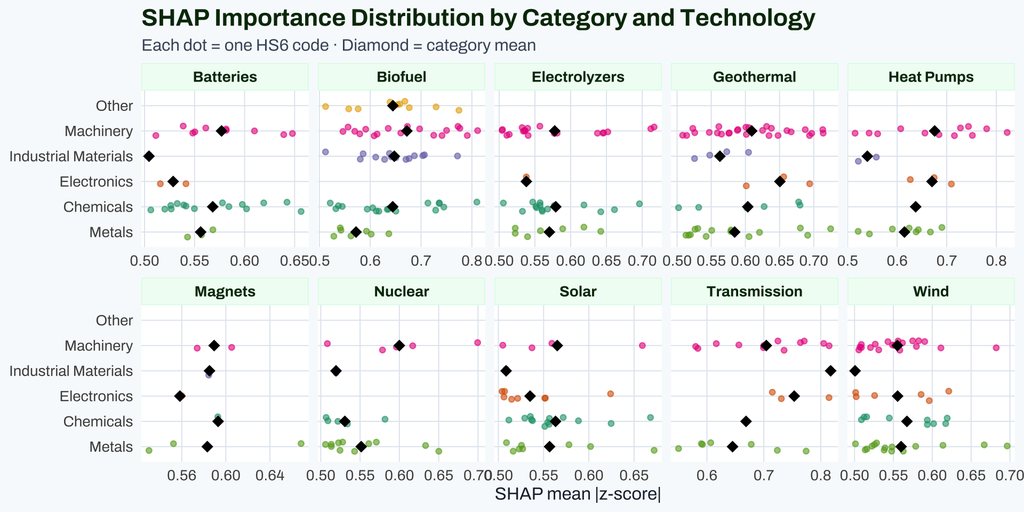

```r
feat |>
  filter(!is.na(hs_code)) |>
  mutate(tech = factor(tech, levels = names(TECH_COLORS))) |>
  ggplot(aes(x = shap_mean_z, y = reorder(category, shap_mean_z),
             color = category)) +
  geom_jitter(height = 0.2, alpha = 0.6, size = 1.5) +
  stat_summary(fun = mean, geom = "point", size = 3.5, shape = 18, color = "black") +
  facet_wrap(~ tech, ncol = 5, scales = "free_x") +
  scale_color_brewer(palette = "Dark2", guide = "none") +
  labs(title = "SHAP Importance Distribution by Category and Technology",
       subtitle = "Each dot = one HS6 code · Diamond = category mean",
       x = "SHAP mean |z-score|", y = NULL) +
  theme_nzipl()
```

## 4.3 Top-10 SHAP features per technology

```r
feat |>
  filter(!is.na(hs_code)) |>
  group_by(tech) |>
  slice_max(shap_mean_z, n = 10) |>
  ungroup() |>
  mutate(hs_code = formatC(as.integer(hs_code), width = 6, flag = "0"),
         shap_mean_z = round(shap_mean_z, 4)) |>
  select(Technology = tech, `HS Code` = hs_code,
         Description = description, Category = category,
         `SHAP mean |z|` = shap_mean_z) |>
  kable(caption = "Top-10 SHAP features per technology (by mean |z-score|)") |>
  kable_styling(bootstrap_options = c("striped","hover","condensed"),
                full_width = TRUE, font_size = 11) |>
  row_spec(0, bold = TRUE, background = nzipl_green, color = "white") |>
  collapse_rows(columns = 1, valign = "middle")
```

Top-10 SHAP features per technology (by mean |z-score|)

| Technology | HS Code | Description | Category | SHAP mean &#124;z&#124; |
| --- | --- | --- | --- | --- |
| Batteries | 391190 | Polysulphides, polysulphones and similar products of chemical synthesis n.e.s. in chapter 39; in primary forms | Chemicals | 0.6565 |
|  | 847990 | Machines and mechanical appliances; parts, of those having individual functions | Machinery | 0.6478 |
|  | 370130 | Photographic plates and film; in the flat, sensitised, unexposed, with any side exceeding 225mm, of any materials other than paper, paperboard or textiles | Chemicals | 0.6424 |
|  | 903190 | Instruments, appliances and machines; parts and accessories for those measuring or checking devices of heading no. 9031 | Machinery | 0.6392 |
|  | 282540 | Nickel oxides and hydroxides | Chemicals | 0.6192 |
|  | 902790 | Microtomes and parts and accessories thereof | Machinery | 0.6099 |
|  | 291030 | Epoxides, epoxyalcohols, epoxyphenols and epoxyethers; with a three-membered ring and their halogenated, sulphonated, nitrated or nitrosated derivatives, 1-chloro-2,3-epoxypropane (epichlorohydrin) | Chemicals | 0.6020 |
|  | 282200 | Cobalt oxides and hydroxides; commercial cobalt oxides | Chemicals | 0.5977 |
|  | 382490 | Chemical products, preparations and residual products of the chemical or allied industries, n.e.s. or included in heading no. 3824 | Chemicals | 0.5843 |
|  | 903180 | Instruments, appliances and machines; for measuring or checking n.e.s. in chapter 90 | Machinery | 0.5817 |
| Biofuel | 940390 | Furniture; parts | Machinery | 0.8113 |
|  | 381590 | Reaction initiators, reaction accelerators and catalytic preparations, unsupported, n.e.s. or included | Chemicals | 0.8098 |
|  | 844190 | Machinery; parts of machinery for making up paper pulp, paper or paperboard, including cutting machines of all kinds | Machinery | 0.7910 |
|  | 841939 | Dryers; for products n.e.s. in heading no. 8419, not used for domestic purposes | Machinery | 0.7764 |
|  | 121299 | Vegetable products (including unroasted chicory roots, chicorium intybus sativum variety); n.e.s. in chapter 12, fresh, chilled, frozen or dried, ground or unground, primarily for human consumption | Other | 0.7746 |
|  | 841381 | Pumps and liquid elevators; n.e.s. in heading no. 8413 | Machinery | 0.7726 |
|  | 441520 | Wood; pallets, box pallets and other load boards; pallet collars | Industrial Materials | 0.7718 |
|  | 842121 | Machinery; for filtering or purifying water | Machinery | 0.7502 |
|  | 281122 | Silicon dioxide | Chemicals | 0.7448 |
|  | 841410 | Pumps; vacuum | Machinery | 0.7413 |
| Electrolyzers | 845610 | Machine-tools; operated by laser or other light or photon beam process | Machinery | 0.7167 |
|  | 841480 | Pumps and compressors; for air, vacuum or gas, n.e.s. in heading no. 8414 | Machinery | 0.7120 |
|  | 390710 | Polyacetals; in primary forms | Chemicals | 0.6961 |
|  | 381512 | Catalysts, supported; reaction initiators, reaction accelerators and catalytic preparations, with precious metal or precious metal compounds as the active substance, n.e.s. or included | Chemicals | 0.6612 |
|  | 842121 | Machinery; for filtering or purifying water | Machinery | 0.6519 |
|  | 841370 | Pumps; centrifugal, n.e.s. in heading no. 8413, for liquids | Machinery | 0.6458 |
|  | 841490 | Pumps and compressors; parts, of air or vacuum pumps, air or other gas compressors and fans, ventilating or recycling hoods incorporating a fan | Machinery | 0.6453 |
|  | 381519 | Catalysts, supported; reaction initiators, reaction accelerators and catalytic preparations, with an active substance other than nickel or precious metals or their compounds, n.e.s. or included | Chemicals | 0.6421 |
|  | 711021 | Metals; palladium, unwrought or in powder form | Metals | 0.6421 |
|  | 842139 | Machinery; for filtering or purifying gases, other than intake air filters for internal combustion engines | Machinery | 0.6374 |

[output cut: 68 more lines]

# 5 Predicted Competitiveness Scores — What We Have

## 5.1 Country × Technology coverage

```r
pc_top3 <- pc |>
  group_by(tech) |>
  filter(year == max(year)) |>
  slice_max(pc_score, n = 3, with_ties = FALSE) |>
  summarise(Top3 = paste(iso3, collapse = ", "), .groups = "drop")

pc |>
  group_by(tech) |>
  summarise(
    Countries = n_distinct(iso3),
    Years     = paste0(min(year), "–", max(year)),
    `Mean PC` = round(mean(pc_score, na.rm = TRUE), 3),
    .groups = "drop"
  ) |>
  left_join(pc_top3, by = "tech") |>
  rename(Technology = tech, `Top 3 (latest yr)` = Top3) |>
  kable(caption = "Predicted competitiveness coverage") |>
  kable_styling(bootstrap_options = c("striped","hover","condensed"),
                full_width = TRUE, font_size = 13) |>
  row_spec(0, bold = TRUE, background = nzipl_green, color = "white")
```

Predicted competitiveness coverage

| Technology | Countries | Years | Mean PC | Top 3 (latest yr) |
| --- | --- | --- | --- | --- |
| Batteries | 155 | 2003–2024 | 0.050 | KOR, CHN, JPN |
| Biofuel | 155 | 2003–2024 | 0.209 | NLD, ZAF, UGA |
| Electrolyzers | 155 | 2003–2024 | 0.078 | ITA, CHN, KOR |
| Geothermal | 155 | 2003–2024 | 0.130 | DEU, ITA, POL |
| Heat Pumps | 155 | 2003–2024 | 0.142 | CHN, THA, ITA |
| Magnets | 155 | 2003–2024 | 0.049 | CHN, JPN, MYS |
| Nuclear | 155 | 2003–2024 | 0.063 | USA, RUS, CZE |
| Solar | 155 | 2003–2024 | 0.059 | JPN, CHN, MYS |
| Transmission | 155 | 2003–2024 | 0.207 | DNK, AUT, CHN |
| Wind | 155 | 2003–2024 | 0.049 | CHN, DNK, IND |

## 5.2 PC score evolution for key countries

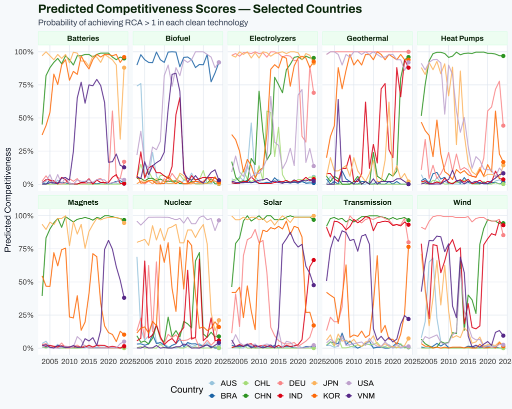

```r
focus <- c("CHN","USA","DEU","IND","KOR","JPN","BRA","VNM","CHL","AUS")

pc |>
  filter(iso3 %in% focus) |>
  mutate(tech = factor(tech, levels = names(TECH_COLORS))) |>
  ggplot(aes(x = year, y = pc_score, color = iso3, group = iso3)) +
  geom_line(linewidth = 0.7, alpha = 0.85) +
  geom_point(data = ~ filter(.x, year == max(year)),
             size = 2) +
  facet_wrap(~ tech, ncol = 5) +
  scale_color_brewer(palette = "Paired", name = "Country") +
  scale_y_continuous(limits = c(0, 1), labels = scales::percent) +
  labs(title = "Predicted Competitiveness Scores — Selected Countries",
       subtitle = "Probability of achieving RCA > 1 in each clean technology",
       x = NULL, y = "Predicted Competitiveness") +
  theme_nzipl() +
  theme(legend.position = "bottom",
        legend.key.size = unit(0.4, "cm"))
```

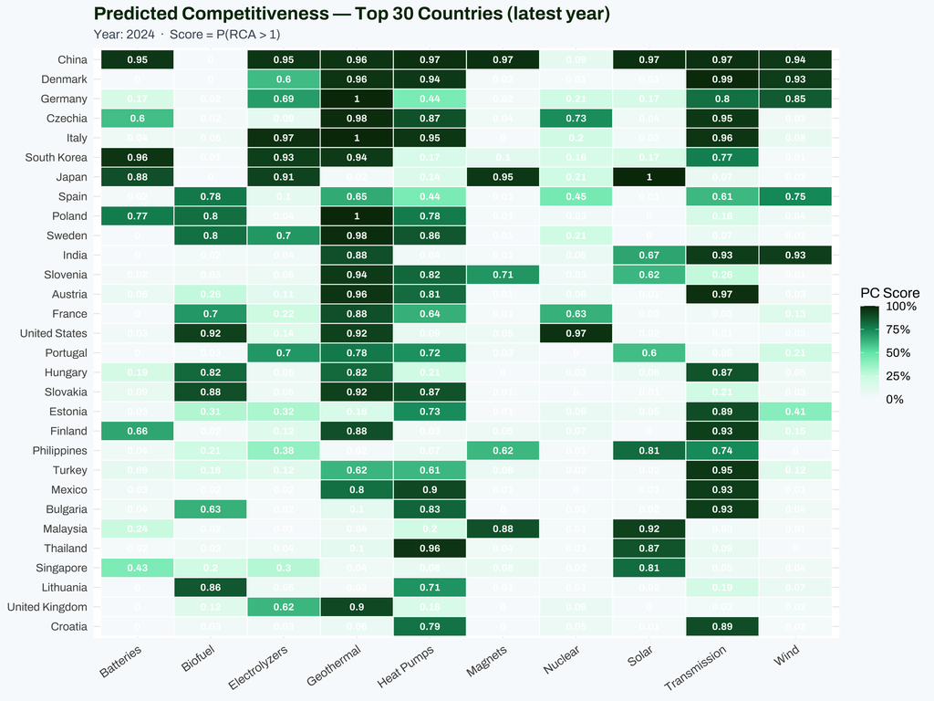

```r
top_countries <- pc |>
  filter(year == max(year)) |>
  group_by(iso3) |>
  summarise(avg_pc = mean(pc_score, na.rm = TRUE), .groups = "drop") |>
  slice_max(avg_pc, n = 30) |>
  pull(iso3)

pc |>
  filter(year == max(year), iso3 %in% top_countries) |>
  mutate(
    country = if_else(is.na(country) | country == "", iso3, country),
    tech    = factor(tech, levels = names(TECH_COLORS))
  ) |>
  ggplot(aes(x = tech, y = reorder(country, pc_score, mean),
             fill = pc_score)) +
  geom_tile(color = "white", linewidth = 0.4) +
  geom_text(aes(label = round(pc_score, 2)),
            size = 3.2, color = "white", fontface = "bold",
            family = "Archivo") +
  scale_fill_gradientn(
    colors  = c("#f8fafc", "#d1fae5", "#6ee7b7", "#059669", nzipl_green),
    limits  = c(0, 1),
    name    = "PC Score",
    labels  = scales::percent
  ) +
  labs(title = "Predicted Competitiveness — Top 30 Countries (latest year)",
       subtitle = paste0("Year: ", max(pc$year),
                        "  ·  Score = P(RCA > 1)"),
       x = NULL, y = NULL) +
  theme_nzipl() +
  theme(axis.text.x = element_text(angle = 35, hjust = 1, size = 11),
        legend.position = "right")
```

# 6 RCA Data — Input to the Model

The `pc_rca.parquet` file contains the actual RCA values used as model features.

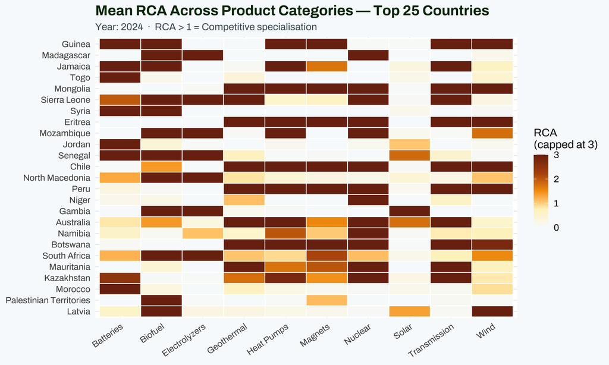

```r
rca_latest <- rca_all |>
  filter(year == max(year)) |>
  group_by(tech, iso3, country, region) |>
  summarise(mean_rca = mean(rca, na.rm = TRUE), .groups = "drop")

top30 <- rca_latest |>
  group_by(iso3) |> summarise(m = mean(mean_rca),.groups="drop") |>
  slice_max(m, n = 25) |> pull(iso3)

rca_latest |>
  filter(iso3 %in% top30) |>
  mutate(country = if_else(is.na(country) | country == "", iso3, country),
         tech = factor(tech, levels = names(TECH_COLORS))) |>
  ggplot(aes(x = tech, y = reorder(country, mean_rca, mean),
             fill = pmin(mean_rca, 3))) +
  geom_tile(color = "white", linewidth = 0.4) +
  scale_fill_gradientn(
    colors = c("#f8fafc", "#fef3c7", "#f59e0b", "#b45309", "#7c2d12"),
    name   = "RCA\n(capped at 3)",
    limits = c(0, 3)
  ) +
  labs(title = "Mean RCA Across Product Categories — Top 25 Countries",
       subtitle = paste0("Year: ", max(rca_all$year),
                        "  ·  RCA > 1 = Competitive specialisation"),
       x = NULL, y = NULL) +
  theme_nzipl() +
  theme(axis.text.x = element_text(angle = 35, hjust = 1))
```

# 7 Why SHAP Correlates with Trade — and What It Means

## 7.1 The causal logic

**Product-space theory**

The NZIPL model is grounded in **economic complexity theory** (Hidalgo & Hausmann 2009). Products that are “proximate” — meaning countries tend to export them together — share underlying productive capabilities (skilled labour, specialised equipment, supply chain infrastructure). The Random Forest is learning this capability-sharing structure: *countries that already have RCA in upstream/related products are more likely to develop RCA in the target technology.*

SHAP measures the contribution of each input RCA variable to the model’s prediction. High-SHAP products are the most informative *capability proxies* for the target technology.

## 7.2 Observed correlation is not circularity

```r
feat |>
  filter(!is.na(hs_code)) |>
  group_by(tech, category) |>
  summarise(
    n          = n(),
    mean_shap  = round(mean(shap_mean_z), 4),
    sd_shap    = round(sd(shap_mean_z), 4),
    .groups    = "drop"
  ) |>
  rename(Technology = tech, Category = category,
         `N codes` = n, `Mean SHAP |z|` = mean_shap,
         `SD SHAP` = sd_shap) |>
  arrange(Technology, desc(`Mean SHAP |z|`)) |>
  kable(caption = "Average SHAP importance by technology × SHAP category") |>
  kable_styling(bootstrap_options = c("striped","hover","condensed"),
                full_width = TRUE, font_size = 12) |>
  row_spec(0, bold = TRUE, background = nzipl_green, color = "white") |>
  collapse_rows(columns = 1, valign = "middle")
```

Average SHAP importance by technology × SHAP category

| Technology | Category | N codes | Mean SHAP &#124;z&#124; | SD SHAP |
| --- | --- | --- | --- | --- |
| Batteries | Machinery | 10 | 0.5770 | 0.0442 |
|  | Chemicals | 15 | 0.5682 | 0.0471 |
|  | Metals | 3 | 0.5561 | 0.0127 |
|  | Electronics | 2 | 0.5286 | 0.0181 |
|  | Industrial Materials | 1 | 0.5044 | NA |
| Biofuel | Machinery | 18 | 0.6721 | 0.0884 |
|  | Industrial Materials | 14 | 0.6474 | 0.0641 |
|  | Other | 10 | 0.6446 | 0.0787 |
|  | Chemicals | 17 | 0.6442 | 0.0871 |
|  | Metals | 7 | 0.5721 | 0.0394 |
| Electrolyzers | Chemicals | 15 | 0.5791 | 0.0520 |
|  | Machinery | 19 | 0.5777 | 0.0690 |
|  | Metals | 7 | 0.5702 | 0.0474 |
|  | Electronics | 1 | 0.5380 | NA |
| Geothermal | Electronics | 3 | 0.6505 | 0.0467 |
|  | Machinery | 27 | 0.6092 | 0.0620 |
|  | Chemicals | 6 | 0.6035 | 0.0740 |
|  | Metals | 14 | 0.5842 | 0.0708 |
|  | Industrial Materials | 4 | 0.5627 | 0.0340 |
| Heat Pumps | Machinery | 12 | 0.6756 | 0.0994 |
|  | Electronics | 3 | 0.6703 | 0.0416 |
|  | Chemicals | 1 | 0.6373 | NA |
|  | Metals | 8 | 0.6147 | 0.0587 |
|  | Industrial Materials | 2 | 0.5398 | 0.0253 |
| Magnets | Chemicals | 1 | 0.5930 | NA |
|  | Machinery | 2 | 0.5894 | 0.0202 |
|  | Industrial Materials | 1 | 0.5852 | NA |
|  | Metals | 3 | 0.5832 | 0.0736 |
|  | Electronics | 1 | 0.5583 | NA |
| Nuclear | Machinery | 5 | 0.5999 | 0.0690 |
|  | Metals | 11 | 0.5515 | 0.0490 |
|  | Chemicals | 5 | 0.5307 | 0.0305 |
|  | Industrial Materials | 1 | 0.5194 | NA |
| Solar | Machinery | 4 | 0.5651 | 0.0665 |
|  | Chemicals | 13 | 0.5632 | 0.0426 |
|  | Metals | 8 | 0.5566 | 0.0570 |
|  | Electronics | 8 | 0.5350 | 0.0408 |
|  | Industrial Materials | 1 | 0.5085 | NA |
| Transmission | Industrial Materials | 1 | 0.8174 | NA |
|  | Electronics | 3 | 0.7534 | 0.0535 |
|  | Machinery | 12 | 0.7043 | 0.0807 |
|  | Chemicals | 1 | 0.6687 | NA |
|  | Metals | 7 | 0.6450 | 0.0819 |
| Wind | Chemicals | 9 | 0.5674 | 0.0467 |
|  | Metals | 15 | 0.5599 | 0.0571 |
|  | Electronics | 6 | 0.5554 | 0.0520 |
|  | Machinery | 19 | 0.5552 | 0.0436 |
|  | Industrial Materials | 1 | 0.5007 | NA |

**Interpretation guide:**

[output not shown]

The narrow observed range (0.50–0.82) across all products indicates that **all features in the final dataset passed a threshold filter** — only above-threshold features were exported to CSV. The absolute scale is less important than the *relative ranking* within a technology.

# 8 Replication Roadmap in CVCE (R)

## 8.1 Feasibility assessment

```r
components <- tribble(
  ~Component,              ~Original,                    ~R_equivalent,          ~Status,           ~Difficulty,
  "RCA calculation",       "pandas/numpy",               "Already in CVCE pipeline (bilateral_ds)", "✅ Done", "Easy",
  "Product proximity (φ)", "Custom scipy/pandas",        "Compute from bilateral_ds with dplyr", "🔲 Missing", "Hard",
  "Feature matrix",        "10 per-tech Python notebooks", "New 11_build_ml_features.R", "🔲 Missing", "Medium",
  "KNN imputation",        "sklearn KNNImputer",         "VIM::kNN() or missForest", "🔲 Missing", "Easy",
  "Random Forest",         "sklearn RandomForestClassifier", "ranger (faster, same accuracy)", "🔲 Missing", "Easy",
  "SHAP values",           "shap.TreeExplainer",         "fastshap or treeshap", "🔲 Missing", "Easy",
  "PC scores export",      "predict_proba[:,1]",         "ranger predictions",  "🔲 Missing", "Easy",
  "Model validation",      "GridSearchCV 5-fold",        "caret or tidymodels",  "🔲 Missing", "Medium"
)

components |>
  kable(col.names = c("Component", "Original (Python)", "R Equivalent",
                      "Status", "Difficulty"),
        caption = "CVCE replication roadmap: Python → R") |>
  kable_styling(bootstrap_options = c("striped","hover","condensed"),
                full_width = TRUE, font_size = 13) |>
  column_spec(4, bold = TRUE) |>
  row_spec(0, bold = TRUE, background = nzipl_green, color = "white")
```

CVCE replication roadmap: Python → R

[output not shown]

## 8.2 Proposed R implementation

The replication would add one new build script to the CVCE pipeline:

```r
# scripts/build_data/11_build_ml_pc.R  (proposed)
#
# Replicates the Python NZIPL ML pipeline in R:
#   1. Compute RCA matrix from bilateral_ds
#   2. Build product proximity (phi) using co-export correlation
#   3. Construct per-tech feature matrices (lagged RCA + macro)
#   4. Train ranger Random Forest (equivalent to sklearn RFC)
#   5. Compute SHAP values via fastshap
#   6. Export pc_scores.parquet + pc_features.csv (replacing datawheel inputs)

library(ranger)     # RF: similar to sklearn RFC
library(fastshap)   # SHAP values for any ML model
library(VIM)        # KNN imputation
```

**Key advantage of replication:** - Re-run with each BACI update (currently 2024 data available, model trained on 2023) - Add new features: ORBIS firm counts, patent data, supply chain distance - Extend to new technologies or product-type subsets - Produce SHAP values at the country-year level (not just aggregated)

## 8.3 The one hard piece: Product Proximity

The phi matrix (product-product proximity, used to identify which non-technology products to include as features) is the only component that requires significant new code. The formula is:

```
φ(p,p') = min[ P(RCA_p | RCA_p'), P(RCA_p' | RCA_p) ]
        = min[ (countries with RCA>1 in both) / (countries with RCA>1 in p),
               (countries with RCA>1 in both) / (countries with RCA>1 in p') ]
```

This can be computed from the existing bilateral data in R, but requires iterating over ~5,000 HS6 pairs, which is computationally intensive (~2–4 hours for full matrix, or ~10 min for the green tech subset).

# 9 Known Limitations

```r
limits <- tribble(
  ~Issue,                   ~Description,                                    ~Severity,
  "Survivorship bias",      "Only countries with continuous trade records included; sparse traders dropped", "Medium",
  "Forward SHAP bias",      "SHAP computed on full dataset, not temporally held-out test set", "High",
  "Lag depth",              "1-year lag may be insufficient for policy impacts (typically 2–3 years)", "Low",
  "Hyperparameter tuning",  "Fixed params (n=100, depth=10) across all techs; Solar/Wind only ones with GridSearchCV", "Medium",
  "Class imbalance",        "Not handled; ~10-40% of country-years are 'competitive' depending on tech", "Medium",
  "RCA volatility",         "Single extreme trade events can spike RCA for one year", "Low",
  "Target variable scope",  "RCA > 1 on any category; not distinguishing manufacturing vs raw material competitiveness", "Medium",
  "SHAP range compression", "Only above-threshold features exported; absolute z-scores not comparable across techs", "Low"
)

limits |>
  kable(col.names = c("Issue", "Description", "Severity"),
        caption = "Known model limitations") |>
  kable_styling(bootstrap_options = c("striped","hover","condensed"),
                full_width = TRUE, font_size = 13) |>
  column_spec(3,
    color = ifelse(limits$Severity == "High", "#dc2626",
                   ifelse(limits$Severity == "Medium", "#d97706", "#16a34a")),
    bold = TRUE) |>
  row_spec(0, bold = TRUE, background = nzipl_green, color = "white")
```

Known model limitations

[output not shown]

# 10 Data Files Summary

```r
tribble(
  ~File,                      ~Rows,    ~Columns,       ~Source,
  "data/pc/pc_features.csv",  paste0(nrow(feat), " (", sum(!is.na(feat$hs_code)), " with HS code)"),
                               "tech, hs_code, description, category, shap_mean_z",
                               "Consolidated from 10 per-tech SHAP CSVs",
  "data/pc/pc_scores.parquet", format(nrow(pc), big.mark=","),
                               "year, iso3, tech, pc_score, country, region",
                               "predicted_competitiveness sheet of nzipl_data_20251006.xlsx",
  "data/pc/pc_rca.parquet",   format(nrow(rca_all), big.mark=","),
                               "iso3, category, tech, year, rca, country, region",
                               "rca_{tech} sheets of nzipl_data_20251006.xlsx",
  "data/pc/pc_countries.csv", format(nrow(ctry), big.mark=","),
                               "iso3, country, region",
                               "country sheet of nzipl_data_20251006.xlsx"
) |>
  kable(col.names = c("File", "Rows", "Columns", "Source"),
        caption = "CVCE data/pc/ file inventory") |>
  kable_styling(bootstrap_options = c("striped","hover","condensed"),
                full_width = TRUE, font_size = 12) |>
  column_spec(1, monospace = TRUE, bold = TRUE) |>
  row_spec(0, bold = TRUE, background = nzipl_green, color = "white")
```

CVCE data/pc/ file inventory

| File | Rows | Columns | Source |
| --- | --- | --- | --- |
| data/pc/pc_features.csv | 402 (357 with HS code) | tech, hs_code, description, category, shap_mean_z | Consolidated from 10 per-tech SHAP CSVs |
| data/pc/pc_scores.parquet | 34,100 | year, iso3, tech, pc_score, country, region | predicted_competitiveness sheet of nzipl_data_20251006.xlsx |
| data/pc/pc_rca.parquet | 171,120 | iso3, category, tech, year, rca, country, region | rca_{tech} sheets of nzipl_data_20251006.xlsx |
| data/pc/pc_countries.csv | 155 | iso3, country, region | country sheet of nzipl_data_20251006.xlsx |

*Generated by NZIPL Clean Value Chain Explorer · May 20, 2026*